# Careem take home test

### Load Data

```r
raw_data <- read.csv("train.csv" , stringsAsFactors = FALSE)
head(raw_data)
```

#### Change data type to factor wherever number of levels < 7

```r
data_type_df <- as.data.frame(sapply(raw_data, class), col.names ="type" )
colnames(data_type_df) <- "type"
data_type_df$type <- as.character(data_type_df$type)
data_type_df$unique_count <- -1
data_type_df$na_flag <- FALSE
data_type_df["X", "unique_count"]

for (col in colnames(raw_data) ) {
    no_of_unique_value = (length(unique(raw_data[,col])))
    data_type_df[col, "unique_count"] <- no_of_unique_value

    if (sum(is.na(raw_data[ , col ])) > 0){
        data_type_df[col, "na_flag"] <- TRUE
    }

    if (no_of_unique_value < 7){
        if (no_of_unique_value > 2){
        raw_data[ , col ] <- as.factor(raw_data[ , col ])
        data_type_df[col, "type"] <- "factor"
            }
    }
}
print(dim(raw_data))
data_type_df
```

### Some type conversions

– creation_date to date from string – rating as numeric and factor – ad variable average-speed in kmph

# 1.1 We think, the higher a captain’s average speed the higher his/her rating. We think customers like speedy rides!

**** 150 km perhour is resonable high speed. So anything more than that has some data-collection issue probably So removing such data.

##### Check the distribution of average speead by rating

[output not shown]

##### Check the density of average speead by rating

[output not shown]

[output not shown]

[output cut: 8 more lines]

##### Trip Rating Histogram - Most people rate 5 or do-not rate

[output not shown]

[figure not shown]

#### 1.1 At aggreagte level there does not apear to be relation between average Speed and rating

#### Null hypothesis average speed in each rating group(1-5) is same

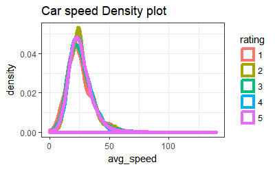

```r
ggplot(filter(raw_data, avg_speed < 150,
                rating_numeric > 0)) +
  geom_density(aes(x=avg_speed, color = rating), size = 2) +
  ggtitle("Car speed Density plot")+
  theme_bw()
```

#### Lets zoom in and observe -

##### Segmentation

- where speed is > 60km per hour = Hi-speed - and this metric will be used for propotion
- 4 and 5 rating are considered high. Thus we have 2 groups of rating

Null hypothesis = percentage of trips in hi-speed are less than or equal to percentage of trips in Low rating group – see plot for result

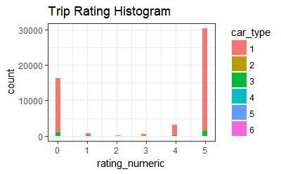

```r
ggplot(raw_data) +
  geom_histogram(aes(x=rating_numeric, fill = car_type)) +
  ggtitle( "Trip Rating Histogram")+
  theme_bw()
```

## 1.2. Our customers can request a trip price estimation by putting the destination address but it’s not required. If a customer requests the price estimation, estimated_price column isn’t empty and contains the price our algorithms predict for the trip. We suppose, there is a dependence: customers are more likely to request a trip price if they are going far.

#### So we define 2 groups as group that requests estimated price and the other that doe not. And we conduct t-test one sided to see whether the average distance is greater or not in one group, can be inferred or not from the sample dat - results in plot

[figure not shown]

# 2. Hypotheses and insights bringing.

## Cool to warm up, isn’t it? Your understanding of the business process and creativity are rapidly growing and urgently needed at Careem! Inspired by the previous examples, can you come up with a couple of interesting hypotheses and check them out? Explain what you’ve found to your team leader and product manager, convince them that you are right. For example, you can cluster the trips and then give a meaningful descriptions to the groups you found.

##### Deriving some more variables for analysis

[output not shown]

[figure not shown]

##### Visualization : Avg no of trips distribution by time of day - weekday vs weekend

[output not shown]

[output not shown]

[figure not shown]

##### Visualization : Demand Peaks distribution by time of day on different weekdays

[figure not shown]

[output not shown]

[figure not shown]

##### Demand percentage are different for weekdays and weekends.

##### We observe from the sample data that percentage trips on weekend are more after 1 pm

```r
raw_data$weekday <- as.factor(weekdays(raw_data$creation_date, abbreviate = T))
raw_data$hour_of_day <- as.numeric(substr(raw_data$creation_date, 12, 13))
raw_data$hour_of_day_factor <- as.factor(raw_data$hour_of_day)
# There are many ways of doing dicretization. ight now it is based on hunch
raw_data$shift_of_day <- as.factor(case_when(raw_data$hour_of_day<4 ~ "grave-yard",
                                             raw_data$hour_of_day>20 ~ "leisure",
                                             raw_data$hour_of_day>3 ~ "work"
                                             )
                                   )
raw_data$weekday_flag <- as.factor(case_when(raw_data$weekday %in% c("Fri", "Sat") ~ "Weekend",
                                             TRUE ~ "Weekday"
                                             )
                                   )
raw_data$grouped_rating <- as.factor(ifelse(raw_data$rating_numeric > 3, "Hi-rating", "Low-rating"))
raw_data$speed_partion <- as.factor(ifelse(raw_data$avg_speed > 60, "Hi-speed", "Low-speed"))
head(raw_data)
```

|  | X | customer_id | driver_id | creation_date | booking_source | car_type | estimated_distance | distance_travelled | distance_travelled_while_moving | estimated_duration | duration_time | wait_time_initial | wait_time_in_journey | estimated_price | price | is_cancelled | rating | was_rated | rating_numeric | avg_speed | grouped_rating | speed_partion | estimated_price_flag | weekday | hour_of_day | hour_of_day_factor | shift_of_day | weekday_flag |
| --- | --- | --- | --- | --- | --- | --- | --- | --- | --- | --- | --- | --- | --- | --- | --- | --- | --- | --- | --- | --- | --- | --- | --- | --- | --- | --- | --- | --- |
| 1 | 0 | 52400320 | 1838640 | 2017-09-08 11:32:05 | 1 | 1 | 0 | 7.28666 | 7.17712 | 0 | 11 | 18 | 2 | 0 | 17.375184 | 0 | 4 | 1 | 4 | 39.74542 | Hi-rating | Low-speed | 0 | Fri | 11 | 11 | work | Weekend |
| 2 | 1 | 29858456 | 1793472 | 2017-09-08 12:42:33 | 1 | 1 | 0 | 1.25836 | 1.05664 | 0 | 4 | 1 | 1 | 0 | 8.507064 | 0 | 4 | 1 | 4 | 18.87540 | Hi-rating | Low-speed | 0 | Fri | 12 | 12 | work | Weekend |
| 3 | 2 | 30828968 | 1726788 | 2017-09-08 12:46:42 | 2 | 1 | 0 | 14.57820 | 14.44060 | 0 | 16 | 3 | 2 | 0 | 19.745205 | 0 | 5 | 1 | 5 | 54.66825 | Hi-rating | Low-speed | 0 | Fri | 12 | 12 | work | Weekend |
| 4 | 3 | 47974768 | 1181696 | 2017-09-08 13:52:35 | 2 | 1 | 0 | 1.51911 | 1.18684 | 0 | 8 | 0 | 5 | 0 | 10.968003 | 0 | 0 | 0 | 0 | 11.39332 | Low-rating | Low-speed | 0 | Fri | 13 | 13 | work | Weekend |
| 5 | 4 | 59503764 | 2063752 | 2017-09-08 14:18:47 | 2 | 1 | 0 | 11.09320 | 10.67240 | 0 | 19 | 1 | 4 | 0 | 17.595398 | 0 | 5 | 1 | 5 | 35.03116 | Hi-rating | Low-speed | 0 | Fri | 14 | 14 | work | Weekend |
| 6 | 5 | 57190176 | 650924 | 2017-09-08 14:41:22 | 1 | 1 | 0 | 6.31771 | 5.45949 | 0 | 16 | 2 | 7 | 0 | 13.676642 | 0 | 0 | 0 | 0 | 23.69141 | Low-rating | Low-speed | 0 | Fri | 14 | 14 | work | Weekend |

```r
data_type_df
```

|  | type | unique_count | na_flag |
| --- | --- | --- | --- |
| X | integer | 51083 | FALSE |
| customer_id | integer | 9000 | FALSE |
| driver_id | integer | 5676 | FALSE |
| creation_date | character | 50386 | FALSE |
| booking_source | factor | 4 | FALSE |
| car_type | factor | 6 | FALSE |
| estimated_distance | numeric | 5409 | FALSE |
| distance_travelled | numeric | 47384 | FALSE |
| distance_travelled_while_moving | numeric | 47349 | FALSE |
| estimated_duration | integer | 83 | FALSE |

[output cut: 8 more lines]

#### How does distance travelled differs on different days

##### Average distance on different day of week are different - See visulaization -

##### Null hypothesis is rejected

[figure not shown]

#### How does distance travelled differs on different days and weekday vs weekend

##### Average distance on weekday vs weeked - See visulaization -

[figure not shown]

#### How does distance travelled differs during different hours

##### Based on sample data one can infer that average distance travled, do differ

[output not shown]

[output not shown]

[figure not shown]

#### How does distance travelled differs during different hours binned

[output not shown]

[figure not shown]

##### Rating and time of day are not independent

###### We try to see if the *percentage of Hi rating* is same across different time-slots

###### We observe difference in percentage of rating

[output not shown]

[figure not shown]

##### Rating proportions - Hi Rating(4 and 5) vs low rating on weekday vs weekend

###### We try to see if the *percentage of Hi rating* is same on Weekdaya vs Weekend

###### We observe no difference - unable to reject null hypothesis

[output not shown]

[figure not shown]

##### Clustering trips based on following fields

##### I am unable to see some good business centred clusters. I will have to filter data and remove some categorical data may be to see some insights. I can do such analysis if I invest more time.

##### If I do extrinsc evaluation on rating, then most of cluster centre look same for numeric variable

–booking_source – car_type – distance_travelled – duration_time – price – speed_partion – weekday_flag – shift_of_day – rating

```r
aov4 <- aov(distance_travelled~shift_of_day ,
            data =raw_data
            )
summary(aov4)
```

```
                Df  Sum Sq Mean Sq F value   Pr(>F)
shift_of_day     2    1222   611.2   13.74 1.08e-06 ***
Residuals    51080 2272246    44.5
---
Signif. codes:  0 *** 0.001 ** 0.01 * 0.05 . 0.1   1
```

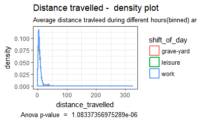

```r
ggplot(raw_data) +
  geom_density(aes(x=distance_travelled, color = shift_of_day), size=1) +
  labs(title = "Distance travelled -  density plot ",
      subtitle = "Average distance travleed during different hours(binned) are different - based on F statistics",
              caption =  paste("Anova p-value  = ",unlist(summary(aov4))[9])
      )+
  theme_bw()
```

##### If time permits , I want to derive for each customer, number of trips, max_distance, average_distance, max_rating, min_rating, median_time_of_day, source_of_order etc and cluster to see if any insight can be generated

–booking_source – car_type – distance_travelled – duration_time – price – rating – speed_partion – weekday_flag – shift_of_day

# 3. Rating prediction

##### Deriving some more variables for analysis

I am deriving several variables her such as week of day, hour of day, average spped. SOme of these variables has been discreetized also, e.g. hour of daya - as order does not makes much sense. Few other variables that has been derived are difference in distance - as those reflect pain point of customers. Few customer specifica and driver specific variables also has been derived. No feature selection has been done as Random-forest is able to select good variables heuristically.

```r
winsorized_data <- filter(raw_data, rating_numeric > 0)
freq_df <- as.data.frame(table(winsorized_data$grouped_rating, winsorized_data$weekday_flag))
freq_df$n <- c(26920, 26920, 7957, 7957)
freq_df$prop <- freq_df$Freq / freq_df$n
freq_df
```

| Var1 | Var2 | Freq | n | prop |
| --- | --- | --- | --- | --- |
| Hi-rating | Weekday | 25771 | 26920 | 0.95731798 |
| Low-rating | Weekday | 1149 | 26920 | 0.04268202 |
| Hi-rating | Weekend | 7613 | 7957 | 0.95676763 |
| Low-rating | Weekend | 344 | 7957 | 0.04323237 |

```r
# 2 proportion test
prop_test <- prop.test(x = c(25771, 7613), n = c(26920, 7957))
(prop_test)
```

```
    2-sample test for equality of proportions with continuity correction

data:  c(25771, 7613) out of c(26920, 7957)
X-squared = 0.032961, df = 1, p-value = 0.8559
alternative hypothesis: two.sided
95 percent confidence interval:
 -0.004610428  0.005711135
sample estimates:
   prop 1    prop 2
0.9573180 0.9567676
```

```r
group_by(winsorized_data, weekday_flag) %>%
  summarise(avg_rating = mean(rating_numeric),
            median_rating = median(rating_numeric)
            )
```

| weekday_flag | avg_rating | median_rating |
| --- | --- | --- |
| Weekday | 4.777637 | 5 |
| Weekend | 4.785221 | 5 |

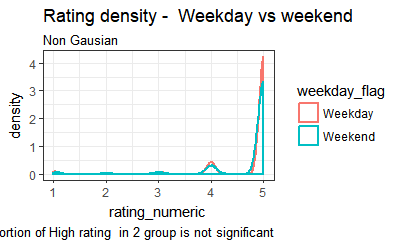

```r
ggplot(winsorized_data) +
  geom_density(aes(x=rating_numeric, color = weekday_flag), size=1) +
  labs(title = "Rating density -  Weekday vs weekend ",
      subtitle = "Non Gausian",
      caption = "Differece between Proportion of High rating  in 2 group is not significant"
      )+
  theme_bw()
```

##### Prepare hold out data in the derived format for scoring purpose

```r
selected_vars <- filter(raw_data , avg_speed<=150) %>%
                  select(booking_source,
                        car_type,
                        distance_travelled,
                        duration_time,
                        price,
                        avg_speed,
                        weekday_flag,
                        shift_of_day,
                        rating
                        )
dmy <- dummyVars("~.", data = selected_vars)
trsf <- data.frame(predict(dmy, newdata = selected_vars))
head(trsf)
```

|  | booking_source.1 | booking_source.2 | booking_source.3 | booking_source.4 | car_type.1 | car_type.2 | car_type.3 | car_type.4 | car_type.5 | car_type.6 | distance_travelled | duration_time | price | avg_speed | weekday_flag.Weekday | weekday_flag.Weekend | shift_of_day.grave.yard | shift_of_day.leisure | shift_of_day.work | rating.0 | rating.1 | rating.2 | rating.3 | rating.4 | rating.5 |
| --- | --- | --- | --- | --- | --- | --- | --- | --- | --- | --- | --- | --- | --- | --- | --- | --- | --- | --- | --- | --- | --- | --- | --- | --- | --- |
| 1 | 1 | 0 | 0 | 0 | 1 | 0 | 0 | 0 | 0 | 0 | 7.28666 | 11 | 17.375184 | 39.74542 | 0 | 1 | 0 | 0 | 1 | 0 | 0 | 0 | 0 | 1 | 0 |
| 2 | 1 | 0 | 0 | 0 | 1 | 0 | 0 | 0 | 0 | 0 | 1.25836 | 4 | 8.507064 | 18.87540 | 0 | 1 | 0 | 0 | 1 | 0 | 0 | 0 | 0 | 1 | 0 |
| 3 | 0 | 1 | 0 | 0 | 1 | 0 | 0 | 0 | 0 | 0 | 14.57820 | 16 | 19.745205 | 54.66825 | 0 | 1 | 0 | 0 | 1 | 0 | 0 | 0 | 0 | 0 | 1 |
| 4 | 0 | 1 | 0 | 0 | 1 | 0 | 0 | 0 | 0 | 0 | 1.51911 | 8 | 10.968003 | 11.39332 | 0 | 1 | 0 | 0 | 1 | 1 | 0 | 0 | 0 | 0 | 0 |
| 5 | 0 | 1 | 0 | 0 | 1 | 0 | 0 | 0 | 0 | 0 | 11.09320 | 19 | 17.595398 | 35.03116 | 0 | 1 | 0 | 0 | 1 | 0 | 0 | 0 | 0 | 0 | 1 |
| 6 | 1 | 0 | 0 | 0 | 1 | 0 | 0 | 0 | 0 | 0 | 6.31771 | 16 | 13.676642 | 23.69141 | 0 | 1 | 0 | 0 | 1 | 1 | 0 | 0 | 0 | 0 | 0 |

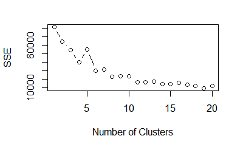

```r
normalize <- function(x){
  return ((x - min(x))/(max(x) - min(x)))}
data_normalized = mutate(trsf,
                         distance_travelled = normalize(distance_travelled),
                         duration_time = normalize(duration_time),
                         price = normalize(price),
                         avg_speed = normalize(avg_speed)
                         )
#head(data_normalized)
#summary(data_normalized)
#kcluster <- kmeans(data_normalized, 3)
SSE_curve <- c()
max_clust = 20
for (n in 1:max_clust) {
  kcluster <- kmeans(data_normalized, n)
  #print(kcluster$withinss)
  sse <- sum(kcluster$withinss)
  SSE_curve[n] <- sse
}
plot(1:max_clust, SSE_curve, type="b", xlab="Number of Clusters", ylab="SSE")
```

```r
kcluster <- kmeans(data_normalized, 2)
#kcluster$size
kcluster$centers
```

```
  booking_source.1 booking_source.2 booking_source.3 booking_source.4 car_type.1 car_type.2 car_type.3   car_type.4   car_type.5   car_type.6
1        0.4991052        0.4987075      0.002154172     3.314111e-05   0.943859 0.01401869 0.04179095 0.0002651289 3.314111e-05 3.314111e-05
2        0.4805479        0.5155461      0.003385240     5.208062e-04   0.936722 0.01036404 0.05244519 0.0004687256 0.000000e+00 0.000000e+00
  distance_travelled duration_time     price avg_speed weekday_flag.Weekday weekday_flag.Weekend shift_of_day.grave.yard shift_of_day.leisure
1         0.02115714     0.0235139 0.2702780 0.1839466            0.7701001            0.2298999              0.02343077           0.05113674
2         0.02233405     0.0242532 0.2797316 0.1808014            0.7787615            0.2212385              0.01906151           0.04489350
  shift_of_day.work  rating.0   rating.1   rating.2   rating.3  rating.4 rating.5
1         0.9254325 0.0000000 0.00000000 0.00000000 0.00000000 0.0000000        1
2         0.9360450 0.7637623 0.03531066 0.01093693 0.02968595 0.1603042        0
```

```r
#kcluster$cluster
```

##### 3.2 Model creation - Decision Tree

```r
library(caret)
library(rpart)
library(rattle)

ggplot(train, aes(x =was_rated, fill = rating))+
         geom_bar(aes(y = (..count..)/sum(..count..))) +
        scale_y_continuous(labels = scales::percent)
#is_cancelled +
rpart1 <- rpart(was_rated ~ car_type + estimated_distance + distance_travelled +
                  distance_travelled_while_moving + estimated_duration + duration_time +
                  wait_time_initial + wait_time_in_journey + estimated_price + weekday +
                  shift_of_day + weekday_flag + avg_rating + max_rating + min_rating + will_rate+
                  price +  avg_speed + toal_trip + is_cancelled + speed_partion + dist_difference+
                  avg_dr_rating + min_dr_rating + will_dr_rate + toal_dr_trip
                  , data = train,
                control = rpart.control(cp = 0.0005, maxdepth = 30, minsplit=10))
#plot(rpart1)
fancyRpartPlot(rpart1)
#rpart1
```

[output not shown]

##### 3.2 Model evaluation - Decision Tree

```r
raw_data <- read.csv("train.csv" , stringsAsFactors = FALSE)
raw_data$creation_date <- as.POSIXct(raw_data$creation_date)
raw_data$rating_numeric <- as.numeric(as.character(raw_data$rating))
raw_data$avg_speed <- 60*raw_data$distance_travelled / raw_data$duration_time
raw_data$grouped_rating <- as.factor(ifelse(raw_data$rating_numeric > 3, "Hi-rating", "Low-rating"))
raw_data$speed_partion <- as.factor(ifelse(raw_data$avg_speed > 60, "Hi-speed", "Low-speed"))
raw_data$weekday <- as.factor(weekdays(raw_data$creation_date, abbreviate = T))
raw_data$hour_of_day <- as.numeric(substr(raw_data$creation_date, 12, 13))
raw_data$hour_of_day_factor <- as.factor(raw_data$hour_of_day)
# There are many ways of doing dicretization. ight now it is based on hunch
raw_data$shift_of_day <- as.factor(case_when(raw_data$hour_of_day<4 ~ "grave-yard",
                                             raw_data$hour_of_day>20 ~ "leisure",
                                             raw_data$hour_of_day>3 ~ "work"
                                             )
                                   )
raw_data$weekday_flag <- as.factor(case_when(raw_data$weekday %in% c("Fri", "Sat") ~ "Weekend",
                                             TRUE ~ "Weekday"
                                             )
                                   )
raw_data$grouped_rating <- as.factor(ifelse(raw_data$rating_numeric > 3, "Hi-rating", "Low-rating"))
raw_data$speed_partion <- as.factor(ifelse(raw_data$avg_speed > 60, "Hi-speed", "Low-speed"))
trip_rating <- read.csv("trip_rating.csv" , stringsAsFactors = FALSE)
#head(trip_rating)
customer_rating_hist <- filter(trip_rating, rating > 0) %>%
                group_by(customer_id) %>%
                summarise(avg_rating = mean(rating),
                          max_rating = max(rating),
                          min_rating = min(rating),
                          trip_ct = n()
                          ) %>%
                full_join(filter(trip_rating, rating == 0) %>%
                          group_by(customer_id) %>%
                          summarise( trip_ct_0 = n()  ))
customer_rating_hist[is.na(customer_rating_hist)] <- 0
customer_rating_hist <- mutate(customer_rating_hist,
                               will_rate = trip_ct/(trip_ct_0+trip_ct)
                              )
driver_rating_hist <- filter(trip_rating, rating > 0) %>%
                group_by(driver_id) %>%
                summarise(avg_dr_rating = mean(rating),
                          max_dr_rating = max(rating),
                          min_dr_rating = min(rating),
                          trip_dr_ct = n()
                          ) %>%
                full_join(filter(trip_rating, rating == 0) %>%
                          group_by(driver_id) %>%
                          summarise( trip_dr_ct_0 = n()  ))
driver_rating_hist[is.na(driver_rating_hist)] <- 0
driver_rating_hist <- mutate(driver_rating_hist,
                               will_dr_rate = trip_dr_ct/(trip_dr_ct_0+trip_dr_ct)
                              )
raw_data2 <- left_join(raw_data, customer_rating_hist) %>%
              left_join(driver_rating_hist)
raw_data2[is.na(raw_data2)] <- 0
```

```
invalid factor level, NA generated
```

```r
raw_data2$was_rated <- as.factor(raw_data2$was_rated)
raw_data2$toal_trip <- (raw_data2$trip_ct + raw_data2$trip_ct_0)
raw_data2$toal_dr_trip <- (raw_data2$trip_dr_ct + raw_data2$trip_dr_ct_0)
raw_data2$dist_difference <- (raw_data2$distance_travelled - raw_data2$distance_travelled_while_moving)
raw_data2
```

[output not shown]

[output cut: 990 more lines]

```r
test_index <-  sample(51083, 0.2*51083, replace = FALSE)
test <- raw_data2[test_index,]
train <- raw_data2[setdiff((1:51083), test_index),]
```

##### 3.3 H2o Radnom Forest setup

```
invalid factor level, NA generated
```

[output not shown]

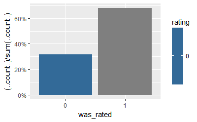

```r
library(caret)
library(rpart)
library(rattle)
ggplot(train, aes(x =was_rated, fill = rating))+
         geom_bar(aes(y = (..count..)/sum(..count..))) +
        scale_y_continuous(labels = scales::percent)
```

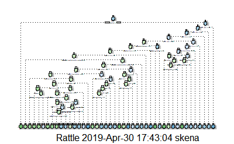

```r
#is_cancelled +
rpart1 <- rpart(was_rated ~ car_type + estimated_distance + distance_travelled +
                  distance_travelled_while_moving + estimated_duration + duration_time +
                  wait_time_initial + wait_time_in_journey + estimated_price + weekday +
                  shift_of_day + weekday_flag + avg_rating + max_rating + min_rating + will_rate+
                  price +  avg_speed + toal_trip + is_cancelled + speed_partion + dist_difference+
                  avg_dr_rating + min_dr_rating + will_dr_rate + toal_dr_trip
                  , data = train,
                control = rpart.control(cp = 0.0005, maxdepth = 30, minsplit=10))
#plot(rpart1)
fancyRpartPlot(rpart1)
```

```r
#rpart1
```

```r
rpartPred1 <- predict(rpart1, test)
pred_y <- (rpartPred1[,2] >= 0.5)*1
error_percentage <- mean(pred_y != test$was_rated)
paste("Miss-classification percentage   " , error_percentage)
```

```
[1] "Miss-classification percentage    0.265563821456539"
```

```r
require(ROCR)
results <- prediction(predictions = rpartPred1[,2], labels = test$was_rated)
auc_s4 <- performance(results, measure = "auc")
paste("AUC     ",auc_s4@y.values[[1]])
```

```
[1] "AUC      0.691240280736174"
```

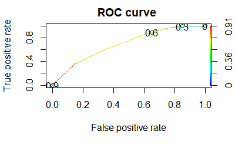

```r
# ROC curve
ROC.curve <- performance(results, measure = "tpr", x.measure = "fpr")
plot(ROC.curve, main = "ROC curve ", colorize=T,
     print.cutoffs.at=seq(0,1,by=0.3))
```

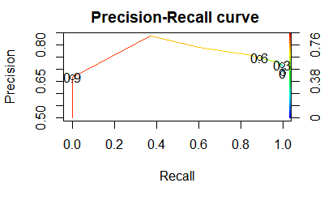

```r
PR.curve <- performance(results, measure = "prec", x.measure = "rec")
plot(PR.curve, main = "Precision-Recall curve ", colorize=T,
     print.cutoffs.at=seq(0,1,by=0.3))
```

##### Apply model on hold-out

```r
library(h2o)
#h2o.shutdown(prompt = FALSE)
localH2O = h2o.init( nthreads = -1)
```

[output not shown]

[output not shown]

```r
#h2o.checkClient(localH2O)
train.h2o <- as.h2o(dplyr::select(train, -c(creation_date))
, destination_frame="train.h2o")
test.h2o <- as.h2o(dplyr::select(test, -c(creation_date))
, destination_frame="test.h2o")
```